# Prediction Assignment Writeup

Wagner Pinheiro

December 2016

## Introduction

Using devices such as Jawbone Up, Nike FuelBand, and Fitbit it is now possible to collect a large amount of data about personal activity relatively inexpensively. These type of devices are part of the quantified self movement – a group of enthusiasts who take measurements about themselves regularly to improve their health, to find patterns in their behavior, or because they are tech geeks. One thing that people regularly do is quantify how much of a particular activity they do, but they rarely quantify how well they do it. In this project, your goal will be to use data from accelerometers on the belt, forearm, arm, and dumbell of 6 participants. They were asked to perform barbell lifts correctly and incorrectly in 5 different ways. More information is available from the website here: http://groupware.les.inf.puc-rio.br/har (see the section on the Weight Lifting Exercise Dataset).

## Getting and Cleaning the Training data

Removing the data with NA and with values close to zero

```
[1] 217 119
```

So, we partition the dataset (70%-30%) to measure the acurancy of the models.

```r
inTrain  <- createDataPartition(training$classe, p=0.7, list=FALSE)
TrainSet <- training[inTrain, ]
TestSet  <- training[-inTrain, ]
dim(TrainSet)
```

```
[1] 154 119
```

```r
dim(TestSet)
```

```
[1]  63 119
```

## Model Building

### 1. Random Forests

```r
# model fit
controlRF <- trainControl(method="cv", number=3, verboseIter=FALSE)
modFitRandForest <- train(classe ~ ., data=TrainSet, method="rf",
                          trControl=controlRF)
modFitRandForest$finalModel
```

```
Call:
 randomForest(x = x, y = y, mtry = param$mtry)
               Type of random forest: classification
                     Number of trees: 500
No. of variables tried at each split: 118

        OOB estimate of  error rate: 22.73%
Confusion matrix:
   A  B  C  D  E class.error
A 31  5  2  0  0   0.1842105
B  7 23  2  1  1   0.3235294
C  3  2 21  0  0   0.1923077
D  5  0  2 18  0   0.2800000
E  0  5  0  0 26   0.1612903
```

```r
predictRandForest <- predict(modFitRandForest, newdata=TestSet)
confMatRandForest <- confusionMatrix(predictRandForest, TestSet$classe)
confMatRandForest
```

```
Confusion Matrix and Statistics

          Reference
Prediction  A  B  C  D  E
         A 12  3  3  3  0
         B  4 10  1  0  1
         C  0  1  7  0  1
         D  0  0  0  7  0
         E  0  0  0  0 10

Overall Statistics

               Accuracy : 0.7302
                 95% CI : (0.6035, 0.8343)
    No Information Rate : 0.254
    P-Value [Acc > NIR] : 3.302e-15

                  Kappa : 0.6567
 Mcnemar's Test P-Value : NA

Statistics by Class:

                     Class: A Class: B Class: C Class: D Class: E
Sensitivity            0.7500   0.7143   0.6364   0.7000   0.8333
Specificity            0.8085   0.8776   0.9615   1.0000   1.0000
Pos Pred Value         0.5714   0.6250   0.7778   1.0000   1.0000
Neg Pred Value         0.9048   0.9149   0.9259   0.9464   0.9623
Prevalence             0.2540   0.2222   0.1746   0.1587   0.1905
Detection Rate         0.1905   0.1587   0.1111   0.1111   0.1587
Detection Prevalence   0.3333   0.2540   0.1429   0.1111   0.1587
Balanced Accuracy      0.7793   0.7959   0.7990   0.8500   0.9167
```

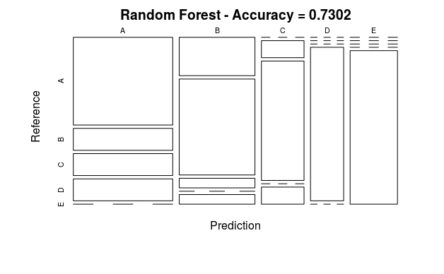

```r
# plot matrix results
plot(confMatRandForest$table, col = confMatRandForest$byClass,
     main = paste("Random Forest - Accuracy =",
                  round(confMatRandForest$overall['Accuracy'], 4)))
```

### 2. Decision Tree

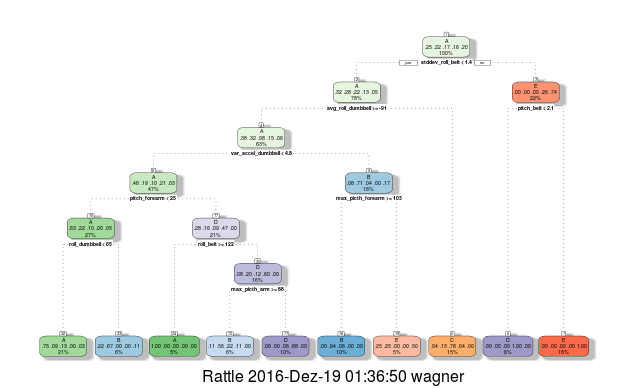

```r
# install.packages(c("rpart", "rpart.plot","rattle"))
library(rpart)
library(rpart.plot)
library(rattle)
# model fit
modFitDecTree <- rpart(classe ~ ., data=TrainSet, method="class")
fancyRpartPlot(modFitDecTree)
```

```r
# prediction on Test dataset
predictDecTree <- predict(modFitDecTree, newdata=TestSet, type="class")
confMatDecTree <- confusionMatrix(predictDecTree, TestSet$classe)
confMatDecTree
```

```
Confusion Matrix and Statistics

          Reference
Prediction  A  B  C  D  E
         A  8  4  3  0  0
         B  3  6  2  2  1
         C  0  1  6  0  1
         D  3  2  0  8  0
         E  2  1  0  0 10

Overall Statistics

               Accuracy : 0.6032
                 95% CI : (0.472, 0.7243)
    No Information Rate : 0.254
    P-Value [Acc > NIR] : 4.937e-09

                  Kappa : 0.5014
 Mcnemar's Test P-Value : NA

Statistics by Class:

                     Class: A Class: B Class: C Class: D Class: E
Sensitivity            0.5000  0.42857  0.54545   0.8000   0.8333
Specificity            0.8511  0.83673  0.96154   0.9057   0.9412
Pos Pred Value         0.5333  0.42857  0.75000   0.6154   0.7692
Neg Pred Value         0.8333  0.83673  0.90909   0.9600   0.9600
Prevalence             0.2540  0.22222  0.17460   0.1587   0.1905
Detection Rate         0.1270  0.09524  0.09524   0.1270   0.1587
Detection Prevalence   0.2381  0.22222  0.12698   0.2063   0.2063
Balanced Accuracy      0.6755  0.63265  0.75350   0.8528   0.8873
```

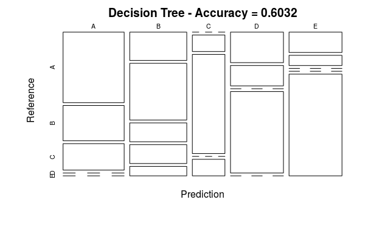

```r
# plot matrix results
plot(confMatDecTree$table, col = confMatDecTree$byClass,
     main = paste("Decision Tree - Accuracy =",
                  round(confMatDecTree$overall['Accuracy'], 4)))
```

### 3. Generalized Boosted Model (GBM)

```r
# model fit
controlGBM <- trainControl(method = "repeatedcv", number = 5, repeats = 1)
modFitGBM  <- train(classe ~ ., data=TrainSet, method = "gbm",
                    trControl = controlGBM, verbose = FALSE)
modFitGBM$finalModel
```

```
A gradient boosted model with multinomial loss function.
100 iterations were performed.
There were 118 predictors of which 90 had non-zero influence.
```

```r
# prediction on Test dataset
predictGBM <- predict(modFitGBM, newdata=TestSet)
confMatGBM <- confusionMatrix(predictGBM, TestSet$classe)
confMatGBM
```

```
Confusion Matrix and Statistics

          Reference
Prediction  A  B  C  D  E
         A 11  3  4  3  0
         B  2 11  1  0  1
         C  1  0  6  0  1
         D  1  0  0  7  0
         E  1  0  0  0 10

Overall Statistics

               Accuracy : 0.7143
                 95% CI : (0.5865, 0.8211)
    No Information Rate : 0.254
    P-Value [Acc > NIR] : 2.507e-14

                  Kappa : 0.6369
 Mcnemar's Test P-Value : NA

Statistics by Class:

                     Class: A Class: B Class: C Class: D Class: E
Sensitivity            0.6875   0.7857  0.54545   0.7000   0.8333
Specificity            0.7872   0.9184  0.96154   0.9811   0.9804
Pos Pred Value         0.5238   0.7333  0.75000   0.8750   0.9091
Neg Pred Value         0.8810   0.9375  0.90909   0.9455   0.9615
Prevalence             0.2540   0.2222  0.17460   0.1587   0.1905
Detection Rate         0.1746   0.1746  0.09524   0.1111   0.1587
Detection Prevalence   0.3333   0.2381  0.12698   0.1270   0.1746
Balanced Accuracy      0.7374   0.8520  0.75350   0.8406   0.9069
```

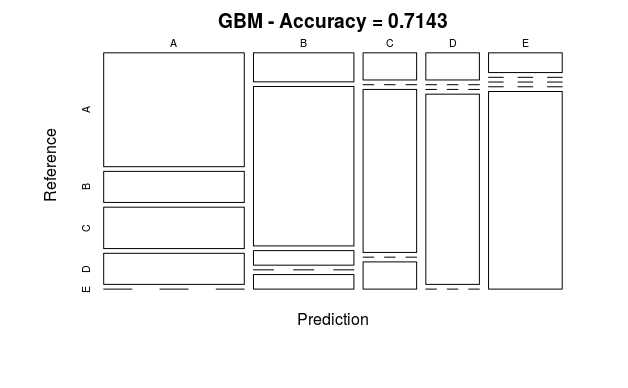

```r
# plot matrix results
plot(confMatGBM$table, col = confMatGBM$byClass,
     main = paste("GBM - Accuracy =", round(confMatGBM$overall['Accuracy'], 4)))
```

## Predicting the testing data

```r
if(!file.exists("./data/pml-testing.csv")){
  download.file("https://d396qusza40orc.cloudfront.net/predmachlearn/pml-testing.csv", "./data/pml-testing.csv")
}
testing  <- read.csv("./data/pml-testing.csv", colClasses = classes, header=T, na.string=c("NA", "#DIV/0!", ""))
classes2 <- sapply(testing, class)
testing <- testing[,-c(1,2,3,4,5)]
#testing <- sapply(testing, as.numeric)
# predictTEST <- predict(modFitRandForest, newdata=testing)
predictTEST <- predict(modFitDecTree, newdata=testing)
# predictTEST <- predict(modFitGBM, newdata=testing)
predictTEST
```

```
           A         B         C         D         E
1  1.0000000 0.0000000 0.0000000 0.0000000 0.0000000
2  0.2500000 0.2500000 0.0000000 0.0000000 0.5000000
3  0.2500000 0.2500000 0.0000000 0.0000000 0.5000000
4  0.0000000 0.9375000 0.0625000 0.0000000 0.0000000
5  0.7500000 0.0937500 0.1250000 0.0000000 0.0312500
6  0.0000000 0.9375000 0.0625000 0.0000000 0.0000000
7  0.2500000 0.2500000 0.0000000 0.0000000 0.5000000
8  0.2500000 0.2500000 0.0000000 0.0000000 0.5000000
9  0.2222222 0.6666667 0.0000000 0.0000000 0.1111111
10 0.7500000 0.0937500 0.1250000 0.0000000 0.0312500
11 0.2222222 0.6666667 0.0000000 0.0000000 0.1111111
12 0.2500000 0.2500000 0.0000000 0.0000000 0.5000000
13 0.7500000 0.0937500 0.1250000 0.0000000 0.0312500
14 0.2500000 0.2500000 0.0000000 0.0000000 0.5000000
15 0.2500000 0.2500000 0.0000000 0.0000000 0.5000000
16 0.7500000 0.0937500 0.1250000 0.0000000 0.0312500
17 0.7500000 0.0937500 0.1250000 0.0000000 0.0312500
18 0.1111111 0.5555556 0.2222222 0.1111111 0.0000000
19 1.0000000 0.0000000 0.0000000 0.0000000 0.0000000
20 0.2500000 0.2500000 0.0000000 0.0000000 0.5000000
```